# Project2

Anh Doan(atd2354)

# **1. Introduction**

The dataset I selected for analysis comprises Premier League Player Statistics from All Seasons, a comprehensive collection of performance metrics for players in one of the most prestigious football leagues globally. The statistics included cover key performance indicators such as goals, assists, matches played, and ages, which can provide insights into both individual player achievements and team dynamics.

**Source Link**: [kaggle](https://www.kaggle.com/datasets/rishikeshkanabar/premier-league-player-statistics-updated-daily/data)

[figure not shown]

**Image**: [Sky Sports](https://e0.365dm.com/24/07/2048x1152/skysports-premier-league-season_6629191.jpg?20240717140210)

I chose this dataset due to my interest in soccer and data analysis. My investigation will focus on understanding player contributions through various metrics, including goals, assists, wins, and losses, and how these factors correlate with overall team success.

# **2. Data Preparation**

To obtain the data, I downloaded a CSV file directly from Kaggle containing the statistics. Using R, I imported the data using **read.csv()** function. Given that I intend to work only with 11 columns, I filtered out unnecessary variables during the import process. Moreover, I removed any rows with N/A values to ensure data consistency and simplify analysis.

One of the main challenges that I encountered was reducing the data to 11 columns. It required a careful balance to retain essential information without losing context, as many variables provided useful insights but weren’t crucial for my specific analysis goals.

# **3. Variables Description**

```
##                  Name      Type                    Description
## 1                Name Character                  Player's Name
## 2       Jersey.Number   Integer         Player's Jersey Number
## 3                Club Character     Team The Player Represents
## 4            Position Character   Position Played on The Field
## 5         Nationality Character           Player's Nationality
## 6                 Age   Integer                   Player's Age
## 7         Appearances   Integer Total Number of Matches Played
## 8                Wins   Integer          Number of Matches Won
## 9              Losses   Integer         Number of Matches Lost
## 10              Goals   Integer             Total goals scored
## 11            Assists   Integer             Total assists made
## 12 Goals Contribution   Integer       Total Goal Contributions
## 13              Class Character      Player's Appearance Class
```

# **4. Univariate Analyses**

### **- Goals Contribution**

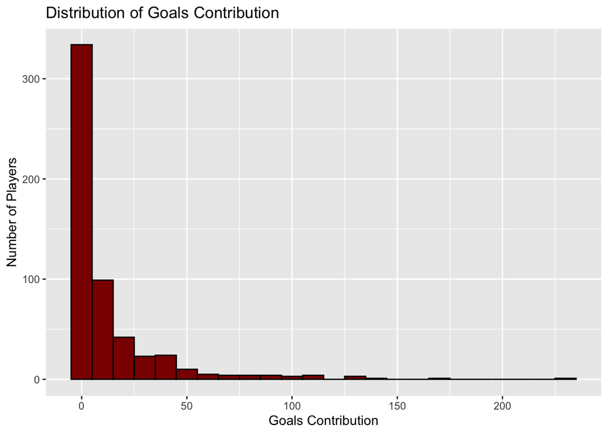

The histogram displays the distribution of goals contribution among a group of players. The distribution is heavily right-skewed, indicating that there are a large number of players with a low number of goals, and a few players with a very high number of goals. The mean number of goals scored is **7.44**, while the median is **1**. Additionally, the standard deviation is **16.92**, reflecting the extent of variability in the number of goals scored among players.

### **- Player’s Age**

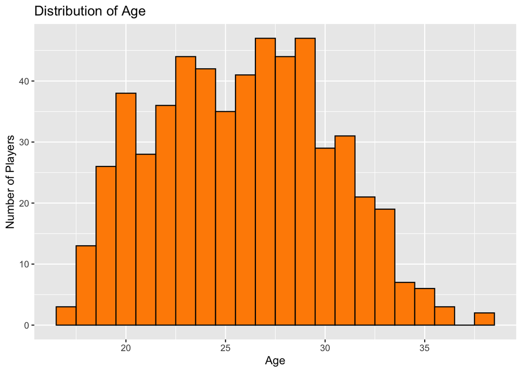

The histogram displays the distribution of ages among players. The distribution appears to be roughly unimodal, with a single peak at the age of **29**. The mean age of the player is **25.81**, while the median is **26**, suggesting that half of the players are younger than this value. Additionally, the standard deviation is **4.36**, providing insight into the variability in ages within the player pool.

### **- Player’s Position**

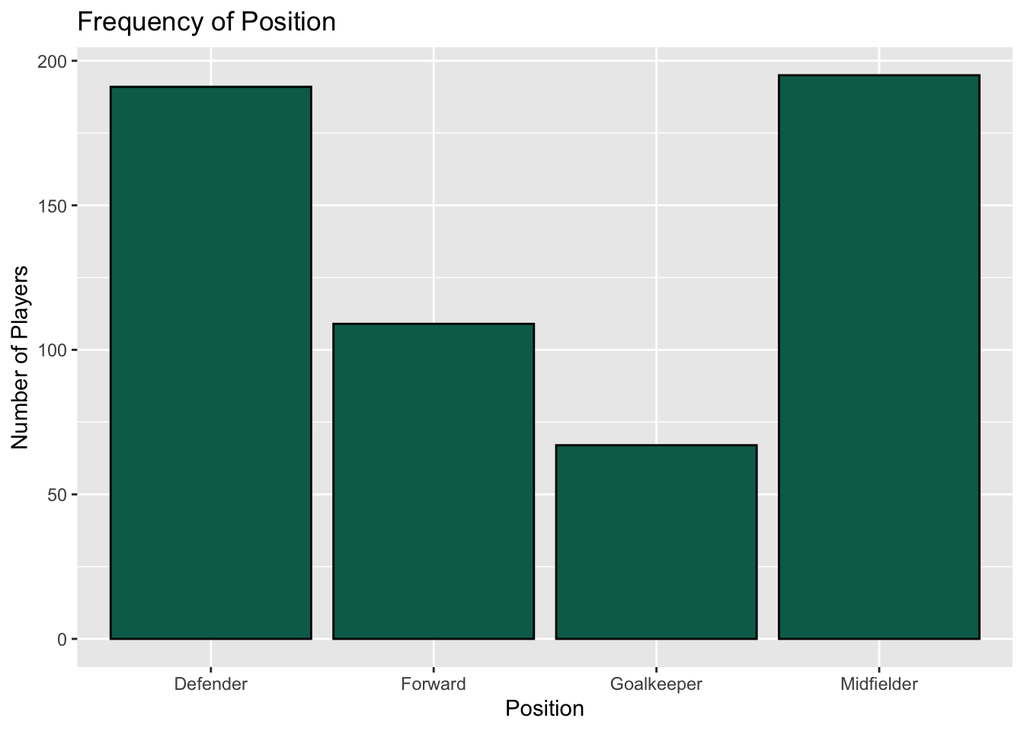

Frequency:

```
##
##   Defender    Forward Goalkeeper Midfielder
##        191        109         67        195
```

The bar chart illustrates the distribution of player positions. Defenders and midfielders dominate, each comprising nearly **200** players. Forwards follow with **109** players, while goalkeepers constitute the smallest group with only **67** players. This distribution suggests a balanced team with a strong defensive and midfield presence, coupled with a sufficient number of attacking players.

### **- Player’s Appearance Class**

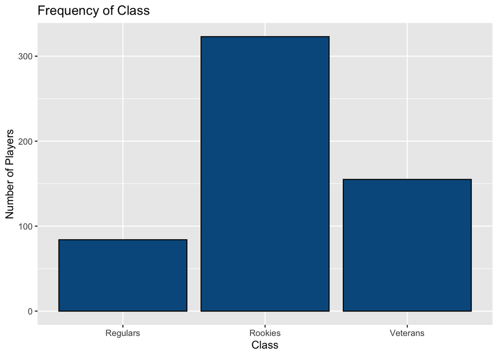

Frequency:

```
##
## Regulars  Rookies Veterans
##       84      323      155
```

The bar chart illustrates the distribution of players across three experience levels: Rookies (Less than 50 Appearances), Regulars (More than 50 Appearances and Less than 100 Appearances) and Veterans (More than 100 Appearances). **84** players are categorized as Regulars, showcasing a moderate level of experience and performance. In contrast, **323** players fall under the Rookies category, indicating a significant presence of newer talent within the league. Lastly, **155** players are identified as Veterans, reflecting their extensive experience and contribution to their respective teams.

# **5. Multivariate Analyses**

### **- Player’s Age vs Player’s Position**

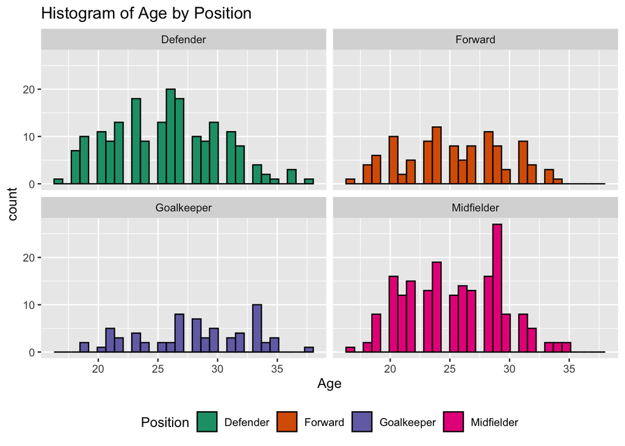

```
## # A tibble: 4 × 5
##   Position   Mean_Age Median_Age Min_Age Max_Age
##   <chr>         <dbl>      <dbl>   <int>   <int>
## 1 Defender       25.6         26      17      38
## 2 Forward        25.4         25      17      34
## 3 Goalkeeper     28.1         28      19      38
## 4 Midfielder     25.4         25      17      35
```

The plot allows us to observe how player age varies across different positions. Defenders and Forwards have similar average ages, around **25** years old. Goalkeepers, on average, are older, with a mean age of **28.1** years. Midfielders have a mean age of **25.4** years, aligning with Forwards and Defenders. The median age for all positions is close to the mean, indicating a relatively symmetric distribution. Notably, the maximum age for Defenders and Goalkeepers reaches **38** years, highlighting the potential for experienced players to extend their careers in these positions.

### **- Total Goals Scored vs Total Assists Made by Class**

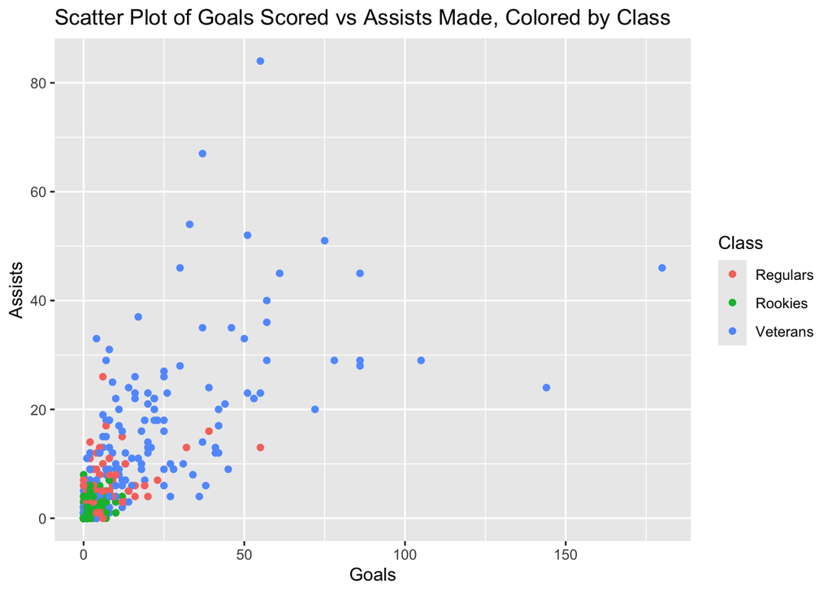

```
## # A tibble: 3 × 5
##   Class    Mean_Goals Median_Goals Mean_Assists Median_Assists
##   <chr>         <dbl>        <dbl>        <dbl>          <dbl>
## 1 Regulars       6.08            4         5.08              4
## 2 Rookies        0.96            0         0.83              0
## 3 Veterans      21.7            12        15.0              11
```

The scatter plot shows how players’ total goals scored relate to their assist counts, with color coding based on class. Players who score a lot may also assist frequently, demonstrating their dual role in offense. Veterans, on average, outperformed both Regulars and Rookies in terms of goals and assists. While Regulars showed a moderate level of performance, Rookies, as expected, had significantly lower averages. The Scatter Plot has a correlation of **0.72**. This positive correlation indicates a strong relationship between the two variables, suggesting that players who score more goals tend to also provide more assists.

### **- Matches Won vs Matches Loss by Big 6 Teams**

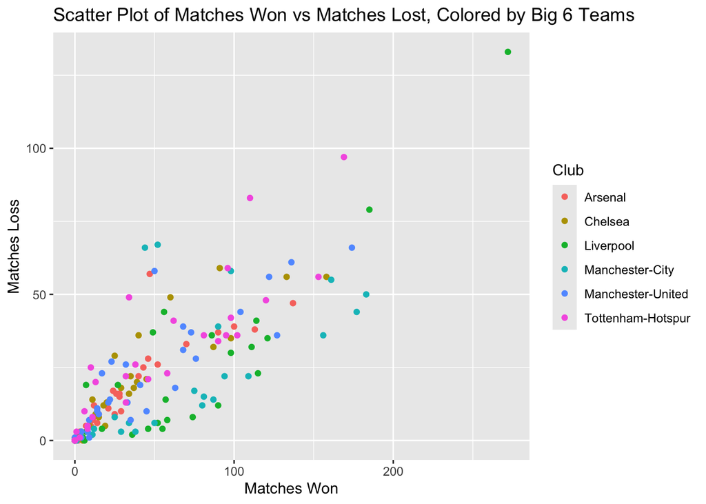

```
## # A tibble: 6 × 5
##   Club              Mean_Wins Median_Wins Mean_Losses Median_Losses
##   <chr>                 <dbl>       <dbl>       <dbl>         <dbl>
## 1 Arsenal                33.5        24.5        16.7          11.5
## 2 Chelsea                39.4        27          20.6          17
## 3 Liverpool              51.6        41          17.6           5
## 4 Manchester-City        67.5        52          22.0          14
## 5 Manchester-United      46.9        32.5        22.4          16
## 6 Tottenham-Hotspur      47.6        32          25.7          22
```

### **- Player’s Age by Club**

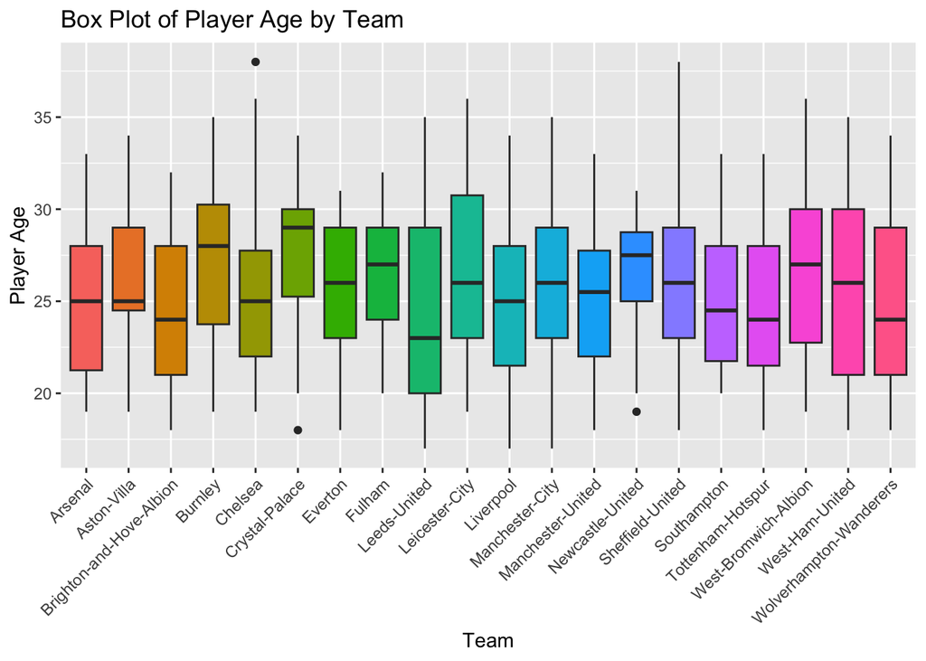

```
## # A tibble: 20 × 5
##    Club                     Mean_Age Median_Age Min_Age Max_Age
##    <chr>                       <dbl>      <dbl>   <int>   <int>
##  1 Arsenal                      25.1       25        19      33
##  2 Aston-Villa                  26.3       25        19      34
##  3 Brighton-and-Hove-Albion     24.4       24        18      32
##  4 Burnley                      27.1       28        19      35
##  5 Chelsea                      25.6       25        19      38
##  6 Crystal-Palace               27.8       29        18      34
##  7 Everton                      25.6       26        18      31
##  8 Fulham                       26.8       27        20      32
##  9 Leeds-United                 24.2       23        17      35
## 10 Leicester-City               26.9       26        19      36
## 11 Liverpool                    25.0       25        17      34
## 12 Manchester-City              25.6       26        17      35
## 13 Manchester-United            25.3       25.5      18      33
## 14 Newcastle-United             26.6       27.5      19      31
## 15 Sheffield-United             26.2       26        18      38
## 16 Southampton                  25.2       24.5      20      33
## 17 Tottenham-Hotspur            25.1       24        18      33
## 18 West-Bromwich-Albion         26.6       27        19      36
## 19 West-Ham-United              26         26        18      35
## 20 Wolverhampton-Wanderers      25         24        18      34
```

The plot reveals how the average age of players varies among clubs. It can show which clubs have a younger or older squad. Crystal Palace has the highest mean age at **27.8**, indicating a more experienced squad, while Leeds United features the youngest average at **24.2**. Most clubs, including Arsenal and Chelsea, maintain average ages around **25 to 26**. The age range among players is quite broad, with the youngest player being **17** years old (Leeds United, Manchester City, and Liverpool) and the oldest reaching **38** (Chelsea and Sheffield United)

# **6. Reproducibility Resources**

**Link to my repository**: [Github Repository](https://github.com/anhdoan0611/Project2)

The GitHub repository contains the following files:

- **“README.md”**: A file providing an overview of the project and instructions for reproducing the analysis.
- **“Project2.csv”**: The data set used for analysis in CSV format.
- **“Project2.Rmd”**: The main report detailing the analysis of player statistics.
- **“Project2.html”**: The HTML version of the report generated from the RMarkdown file.

# **7. Choice Elements**

In this report, I incorporated five key elements: (A) in-line codes, (D) two new variables of interest, (E) manage N/A values, (J) an if statement, and (K) an user-written function. Firstly, I utilized **in-line codes** to seamlessly integrate code snippets within the narrative, specifically highlighted in lines 114, 126, 235, and 271. Secondly, I **created two new variables of interest**: Goals Contribution, which is the sum of goals and assists, and Class, categorizing players into Rookies (less than 50 appearances), Regulars (50 to 99 appearances), and Veterans (100 or more appearances). To ensure the quality of the dataset, I **removed all rows with N/A values**. Lastly, I developed a **user-written function** that utilizes an **if-else statement** to distinguish between character and numeric variables, enabling effective plotting of univariate graphs.

# **8. Conclusion**

In this report, I found notable relationships among player age, position, goal contributions (goals and assists), and team performance in the Premier League dataset.

- **Goals Contribution**: The distribution of goals contribution is heavily right-skewed, with many players scoring few goals and a select few achieving high totals. The mean of 7.44 goals contrasts sharply with the median of 1, underscoring this skew. The high standard deviation (16.92) highlights substantial variability in scoring capabilities across players.
- **Age Distribution**: Player ages are roughly unimodal, peaking around 29 years. The mean age is 25.81, closely aligning with the median age of 26, indicating a generally balanced age distribution. A standard deviation of 4.36 suggests moderate variability, with most players falling within a close age range around the mean.
- **Position Distribution**: Defenders and midfielders make up the largest groups, each with nearly 200 players, highlighting a robust defensive and midfield presence across teams. Forwards and goalkeepers are fewer, with goalkeepers forming the smallest group at 67 players.
- **Experience Levels**: The distribution of experience reveals a league rich in emerging talent, with 323 players categorized as Rookies . Regulars total 84 players, while Veterans comprise 155 players, reflecting a solid mix of new talent and seasoned professionals within the league.
- **Age Distribution by Position**: Defenders and Forwards show similar average ages around 25, while Goalkeepers tend to be older, with an average of 28.1 years. Midfielders align closely with Defenders and Forwards. The relatively symmetric age distribution across positions suggests a balanced spread without extreme age biases.
- **Goals vs Assists by Correlation**: A strong positive correlation **(0.72)** exists between goals scored and assists, suggesting that players who score frequently often contribute significantly in creating goals for others, indicating a dual offensive role.
- **Class Performance**: Veterans generally outperform both Regulars and Rookies in both goals and assists, reflecting their experience and skill. Regulars show moderate performance, while Rookies, as expected, have lower averages in these metrics.
- **Matches Won vs Matches Loss by Big 6 Clubs**: Players from Big 6 clubs show significant performance differences in wins and losses. Manchester City players leads in wins, with Liverpool close behind and holding the second lowest average losses, highlighting efficiency. In contrast, players from Tottenham and Manchester United show higher average losses, pointing to challenges in maintaining a winning consistency.
- **Average Age by Club**: Crystal Palace has the oldest average squad at 27.8 years, indicating experience, while Leeds United has the youngest at 24.2 years. The age range in the league is broad, with players as young as 17 and as old as 38, showcasing the league’s mix of emerging talents and seasoned veterans.

# **9. References**

- **Data Source**: [kaggle](https://www.kaggle.com/datasets/rishikeshkanabar/premier-league-player-statistics-updated-daily/data)